# Forecasting with ARIMA models

10 Apr 2025

## Forecasting with an ARIMA model

The basic idea of forecasting with an ARIMA model to estimate the parameters and forecast forward.

For example, let’s say we want to forecast with a ARIMA(2,1,0) model with drift: \[z_t = \mu + \beta_1 z_{t-1} + \beta_2 z_{t-2} + e_t\] where \(z_t = x_t - x_{t-1}\), the first difference.

`Arima()` would write this model: \[(z_t-m) = \beta_1 (z_{t-1}-m) + \beta_2 (z_{t-2}-m) + e_t\] The relationship between \(\mu\) and \(m\) is \(\mu = m(1 - \beta_1 - \beta_2)\).

Let’s estimate the \(\beta\)’s for this model from the anchovy data.

```r
fit <- forecast::Arima(anchovyts, order=c(2,1,0), include.constant=TRUE)
coef(fit)
```

```
##         ar1         ar2       drift
## -0.53850433 -0.44732522  0.05367062
```

```r
mu <- coef(fit)[3]*(1-coef(fit)[1]-coef(fit)[2])
mu
```

```
##     drift
## 0.1065807
```

So we will forecast with this model:

\[z_t = 0.1065807-0.53850433 z_{t-1} - 0.44732522 z_{t-2} + e_t\]

To get our forecast for 1990, we do this

\[(x_{90}-x_{89}) = 0.106 - 0.538 (x_{89}-x_{88}) - 0.447 (x_{88}-x_{87})\]

Thus

\[x_{90} = x_{89}+0.106 -0.538 (x_{89}-x_{88}) - 0.447 (x_{88}-x_{87})\]

## Forecasting with `forecast()`

`forecast(fit, h=h)` automates the forecast calculations for us and computes the upper and lower prediction intervals. Prediction intervals include uncertainty in parameter estimates plus the process error uncertainty.

```r
fr <- forecast::forecast(fit, h=5)
fr
```

```
##      Point Forecast    Lo 80    Hi 80    Lo 95    Hi 95
## 1990       9.962083 9.702309 10.22186 9.564793 10.35937
## 1991       9.990922 9.704819 10.27703 9.553365 10.42848
## 1992       9.920798 9.623984 10.21761 9.466861 10.37473
## 1993      10.052240 9.713327 10.39115 9.533917 10.57056
## 1994      10.119407 9.754101 10.48471 9.560719 10.67809
```

## Plotting our forecasts

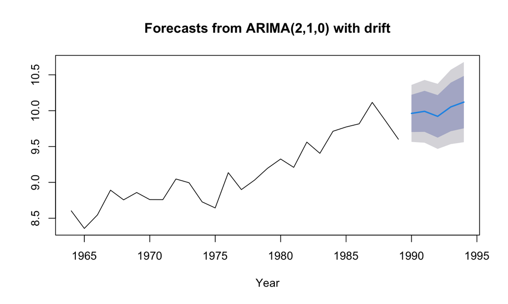

```r
plot(fr, xlab="Year")
```

## Missing values

Missing values are allowed for `forecast::Arima()`. We can produce forecasts with the same code.

```r
anchovy.miss <- anchovyts
anchovy.miss[10:11] <- NA
anchovy.miss[20:21] <- NA
fit <- forecast::Arima(anchovy.miss, order=c(2,1,0), include.constant=TRUE)
fr <- forecast::forecast(fit, h=5)
fr
```

```
##      Point Forecast    Lo 80    Hi 80    Lo 95    Hi 95
## 1990       9.938269 9.664479 10.21206 9.519543 10.35700
## 1991      10.014686 9.700961 10.32841 9.534885 10.49449
## 1992       9.924208 9.601147 10.24727 9.430129 10.41829
## 1993      10.029988 9.666069 10.39391 9.473421 10.58656
## 1994      10.128066 9.729066 10.52707 9.517848 10.73828
```

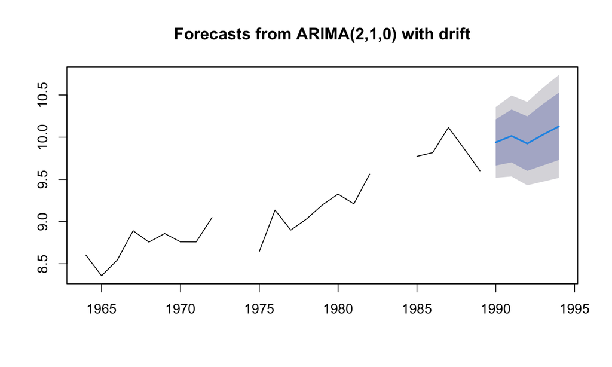

```r
plot(fr)
```

## Using auto.arima()

We can let forecast to select the ARIMA model:

```r
anchovy.miss <- anchovyts
anchovy.miss[10:11] <- NA
anchovy.miss[20:21] <- NA
fit <- forecast::auto.arima(anchovy.miss)
fit
```

```
## Series: anchovy.miss
## ARIMA(0,1,1) with drift
##
## Coefficients:
##           ma1   drift
##       -0.7240  0.0548
## s.e.   0.2283  0.0125
##
## sigma^2 = 0.04355:  log likelihood = 3.52
## AIC=-1.03   AICc=0.11   BIC=2.63
```

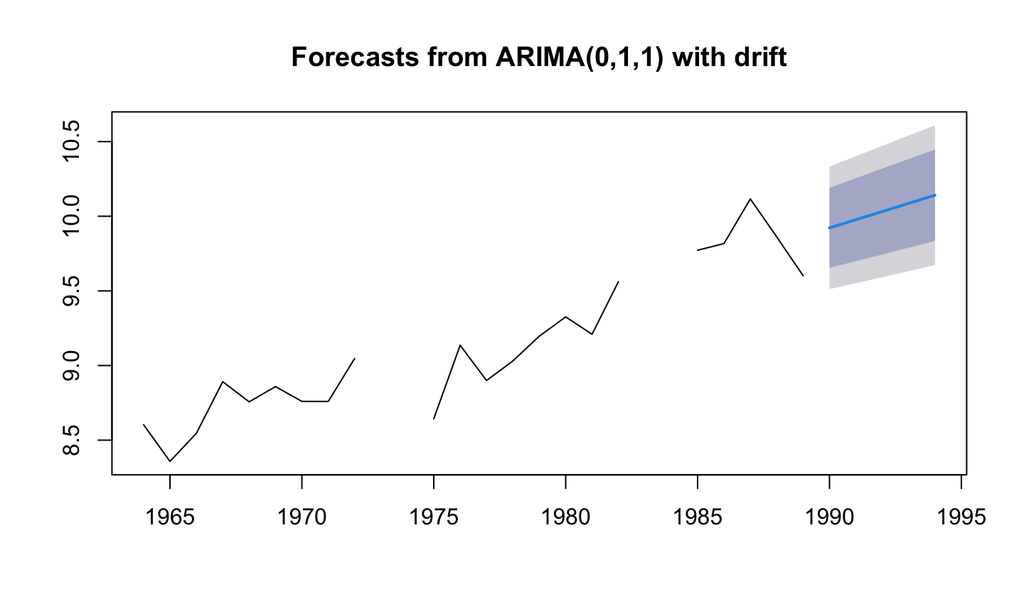

```r
fr <- forecast::forecast(fit, h=5)
plot(fr)
```

## Seasonal ARIMA Models

### Load the chinook salmon data set

```r
load("chinook.RData")
head(chinook)
```

```
##   Year Month Species log.metric.tons metric.tons
## 1 1990   Jan Chinook        3.397858        29.9
## 2 1990   Feb Chinook        3.808882        45.1
## 3 1990   Mar Chinook        3.511545        33.5
## 4 1990   Apr Chinook        4.248495        70.0
## 5 1990   May Chinook        5.200705       181.4
## 6 1990   Jun Chinook        4.371976        79.2
```

The data are monthly and start in January 1990. To make this into a ts object do

```r
chinookts <- ts(chinook$log.metric.tons, start=c(1990,1),
                frequency=12)
```

`start` is the year and month and frequency is the number of months in the year.

Use `?ts` to see more examples of how to set up ts objects.

## Plot seasonal data

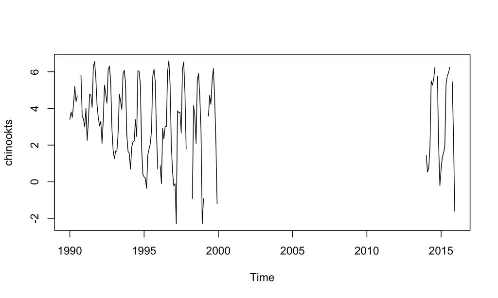

```r
plot(chinookts)
```

## Seasonal ARIMA model: SARIMA

Basic structure of a seasonal AR model

differenced data = AR(non-seasonal) + AR(seasonal) + cross-terms + MA

## Differenced chinook data

- No differencing \(x_t\). We are modeling the data.
- \(x_t - x_{t-1}\). We are modeling the monthly change.
- \(x_t - x_{t-12}\). We are modeling the seasonal change. Jan vs Jan last year, Feb vs Feb last year
- \((x_t - x_{t-12}) - (x_{t-1} - x_{t-13})\). We are modeling the seasonal rate of monthly change.
- \((x_t - x_{t-1}) - (x_{t-12} - x_{t-13})\). We are modeling the seasonal monthly change.

## Notation

ARIMA (p,d,q)(ps,ds,qs)S

ARIMA (non-seasonal part)(seasonal part)Frequency

ARIMA (non-seasonal) means \(t\) correlated with \(t-1\)

ARIMA (seasonal) means \(t\) correlated with \(t-s\)

## Seasonal autoregressive

ARIMA (1,0,0)(1,0,0)[12]

*This month depends on last month plus the same month last year*

What data are we modeling? Zero differences, so

\[z_t = x_t\]

Write out the AR parts with \(z_t\)

\[z_t = \phi_1 z_{t-1} + \Phi_1 z_{t-12} - \text{cross-term} + w_t\]

No MA in this model so \(w_t = e_t\) is white noise.

## Autocorrelated seasonal differences

ARIMA (1,0,0)(1,1,0)[12]

*The seasonal difference this month depends on the seasonal difference last month plus the seasonal difference last year*

\(z_t\) is just a seasonal difference.

\[z_t = x_t - x_{t-12}\]

Write out the AR parts with \(z_t\)

\[z_t = \phi_1 z_{t-1} + \Phi_1 z_{t-12} - \text{cross-term} + w_t\]

No MA in this model so \(w_t = e_t\) is white noise.

## Seasonal random walk model

ARIMA(0,0,0)(0,1,0)[12]

*This month’s value is the same as last year’s, plus some random noise*

expected January 1990 = January 1989 + constant mean

\[z_t = x_t - x_{t-12}\]

No AR nor MA

\[z_t = w_t = x_t - x_{t-12}\] \[x_t = x_{t-12} + w_t\]

## Seasonal random walk model with random trend

ARIMA(0,1,0)(0,1,0)[12]

expected Feb 1990 = Feb 1989 + (Jan 1990 - Jan 1989)

\[z_t = (x_t - x_{t-12}) - (x_{t-1} - x_{t-13})\]

No AR or MA part.

\[z_t = w_t = (x_t - x_{t-12}) - (x_{t-1} - x_{t-13})\] \[x_t = x_{t-12} + (x_{t-1} - x_{t-13}) + w_t\]

## airline model

ARIMA(0, 1, 1)(0, 1, 1)[12]

Seasonal random walk model with random trend + autocorrelated noise

\[z_t = (x_t - x_{t-12}) - (x_{t-1} - x_{t-13})\]

No AR part. Write out the MA parts, the \(w_t\).

\[w_t = e_t - \theta_1 e_{t-1} - \Theta_1 e_{t-12} + \text{cross-term}\]

## `auto.arima()` for seasonal ts

`auto.arima()` will recognize that our data has season and fit a seasonal ARIMA model to our data by default. We will define the training data up to 1998 and use 1999 as the test data.

```r
traindat <- window(chinookts, c(1990,10), c(1998,12))
testdat <- window(chinookts, c(1999,1), c(1999,12))
fit <- forecast::auto.arima(traindat)
fit
```

```
## Series: traindat
## ARIMA(1,0,0)(0,1,0)[12] with drift
##
## Coefficients:
##          ar1    drift
##       0.3676  -0.0320
## s.e.  0.1335   0.0127
##
## sigma^2 = 0.8053:  log likelihood = -107.37
## AIC=220.73   AICc=221.02   BIC=228.13
```

## Forecasting with a Seasonal model

### Load the chinook salmon data

```r
library(atsalibrary)
chinook <- chinook.month %>% subset(State == "WA")
chinookts <- ts(chinook$log.metric.tons, start=c(1990,1),
                frequency=12)
```

## Plot seasonal data

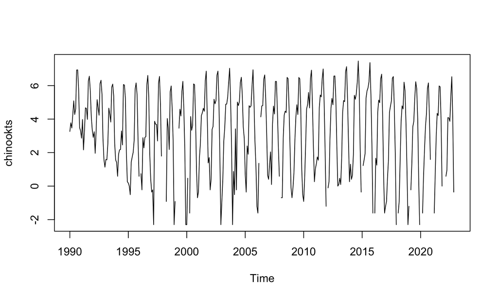

```r
plot(chinookts)
```

## Fit

Missing values are ok when fitting a seasonal ARIMA model

```r
traindat <- window(chinookts, c(1990,10), c(1998,12))
testdat <- window(chinookts, c(1999,1), c(1999,12))
fit <- forecast::auto.arima(traindat)
fit
```

```
## Series: traindat
## ARIMA(1,0,0)(0,1,0)[12] with drift
##
## Coefficients:
##          ar1    drift
##       0.3728  -0.0315
## s.e.  0.1332   0.0127
##
## sigma^2 = 0.7918:  log likelihood = -106.67
## AIC=219.35   AICc=219.64   BIC=226.75
```

## Forecast using seasonal model

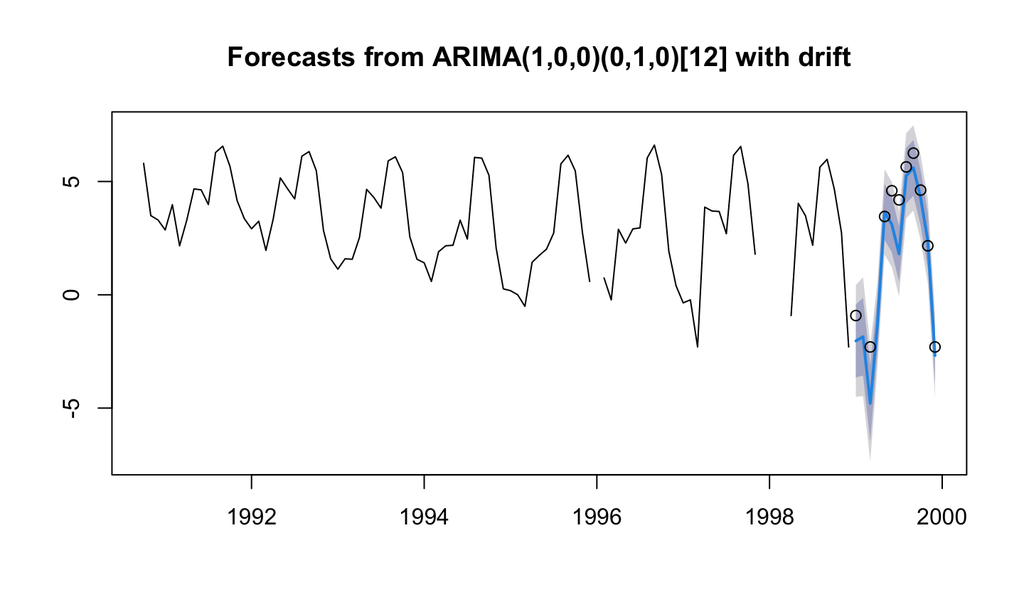

```r
fr <- forecast::forecast(fit, h=12)
plot(fr)
points(testdat)
```